# CEE218X Assignment 2

Ximena Hasbach

10/21/2020

1. An equity analysis of educational attainment by race. Plot the “stacked” and “filled” bar charts as demonstrated in 2.2; from there, you are welcome to add as many comments and supplementary visualizations as you’d like. Essentially, respond to the question: “Is there disproportionate education attainment by race in the County?” Note that the universe of the ACS datasets on educational attainment is “population 25 years or older”, so be sure to clarify that in your visuals and commentary.

County: San Mateo 081

C15002 is Sex By Educational Attainment For The Population 25 Years And Over Have to combine male and female numbers for: 003-006 (male: Less Than High School Diploma, High School Graduate, Some College or Associate’s Degree, Bachelor’s Degree or Higher) and 008-011 (female: Less Than High School Diploma, High School Graduate, Some College or Associate’s Degree, Bachelor’s Degree or Higher)

```
##   code                                  label
## 1  003      Less Than High School Diploma (M)
## 2  004               High School Graduate (M)
## 3  005 Some College or Associate's Degree (M)
## 4  006        Bachelor's Degree or Higher (M)
## 5  008      Less Than High School Diploma (F)
## 6  009               High School Graduate (F)
## 7  010 Some College or Associate's Degree (F)
## 8  011        Bachelor's Degree or Higher (F)
```

```
## [1] "A" "B" "C" "D" "E" "F" "G" "H"
```

```
## # A tibble: 64 x 4
##    county estimate label                            race
##    <chr>     <dbl> <chr>                            <chr>
##  1 081         717 Less than high school diploma    Black or African American
##  2 081        1743 High school graduate (includes … Black or African American
##  3 081        2691 Some college or associate's deg… Black or African American
##  4 081        1867 Bachelor's degree or higher      Black or African American
##  5 081         527 Less than high school diploma    Black or African American
##  6 081        1655 High school graduate (includes … Black or African American
##  7 081        2530 Some college or associate's deg… Black or African American
##  8 081        1874 Bachelor's degree or higher      Black or African American
##  9 081         233 Less than high school diploma    American Indian and Alaska …
## 10 081         127 High school graduate (includes … American Indian and Alaska …
## # … with 54 more rows
```

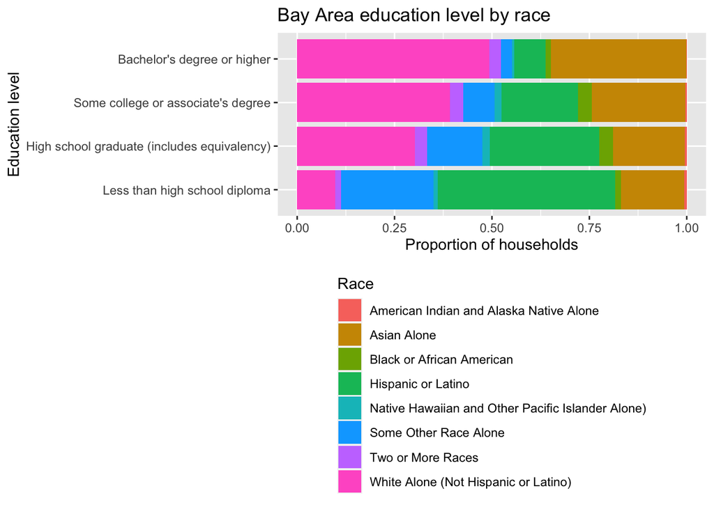

One assumption I made when working with these education-by-race data sets, which is a slight deviation in how similar data was plotted in the class textbook, is that the information for the white population should be drawn from the “White Alone (Not Hispanic or Latino)” dataset. I believe it is important to distinguish between Latinx people who may have Spanish ancestry and white Americans who are not Latinx. From this “Bay Area education levels by race” chart we can clearly see that the white proportion of households increases for higher levels of education, and a similar trend is observed for Asian households. The opposite is seen for Hispanic or Latino households, as well as households who describe themselves as of “Some Other Race.” The Black, biracial, and Native Hawaiian/Pacific Islander populations as seen here are small in comparison to the others mentioned and do not show an obvious pattern.

```
##   code                                  label
## 1  003      Less Than High School Diploma (M)
## 2  004               High School Graduate (M)
## 3  005 Some College or Associate's Degree (M)
## 4  006        Bachelor's Degree or Higher (M)
## 5  008      Less Than High School Diploma (F)
## 6  009               High School Graduate (F)
## 7  010 Some College or Associate's Degree (F)
## 8  011        Bachelor's Degree or Higher (F)
```

```
## [1] "A" "B" "C" "D" "E" "F" "G" "H"
```

```
## # A tibble: 56 x 4
##    county estimate label                                  race
##    <chr>     <dbl> <chr>                                  <chr>
##  1 081       12183 Less than high school diploma          White Alone
##  2 081       20186 High school graduate (includes equiva… White Alone
##  3 081       34490 Some college or associate's degree     White Alone
##  4 081       77155 Bachelor's degree or higher            White Alone
##  5 081       11631 Less than high school diploma          White Alone
##  6 081       21296 High school graduate (includes equiva… White Alone
##  7 081       37754 Some college or associate's degree     White Alone
##  8 081       75714 Bachelor's degree or higher            White Alone
##  9 081         717 Less than high school diploma          Black or African Amer…
## 10 081        1743 High school graduate (includes equiva… Black or African Amer…
## # … with 46 more rows
```

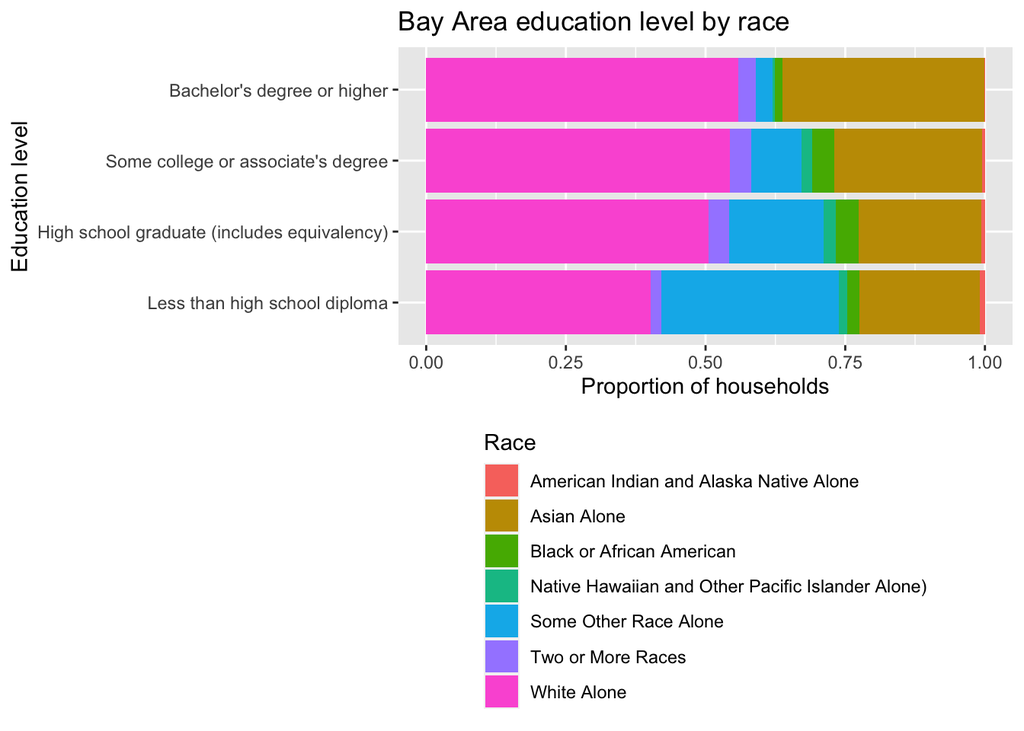

In my opinion the chart above, which includes some Latinx people who identify as White, but otherwise excludes this section of the population, is missing vital information, and by absorbing this more disadvantaged population into the “White” label, it inflates the number of white people with lower levels of education. Latinx identity is complex and cannot necessarily be described as a race, but it is important to see that tracking the Latinx population as a group is still useful.

2. An estimate of the number and percentage of K-12 students who have no internet access at home, using the latest available PUMS data. (Note that 2019 1-yr PUMS data will be available in mid-October 2020, so you might choose to update your analysis using that data at that time.) State your assumptions clearly, especially how useful the available data is for understanding the challenges of remote learning in 2020. Include a map of this metric for all PUMAs in the Bay Area.

I used the HUPAC PUMS variable to obtain the number of households with children, and the ACCESS variable to obtain the number of households without Internet access. My main assumption was that K-12 students are people within households between 5 and 18 years old. I classified a household without Internet access as one whose answer to the ACCESS question was “No access to the Internet at this house, apartment, or mobile home.”

[interactive chart not shown]